# reg_project

### 2-3. 강수량 수준 변수

기상청 기준 강수량 표현

- *비 매우 조금 : 강수량 1mm 미만*
- *비 조금 : 강수량 5mm 미만*
- *비 다소 : 강수량 5～20mm 미만*
- *비 다소 많음 : 강수량 20～80mm 미만*
- *비 많음 : 강수량 80mm 이상(주의보 기준)*
- *비 매우 많음 : 강수량 150mm 이상(경보 기준)*
1. **집단 1. 강수량(0 <= x < 1mm) 맑음 + 비 매우조금**
2. **집단 2. 강수량(1 <= x < 20mm) 비 조금 + 다소**
3. **집단 3. 강수량(20 <= x ) 비 다소 많음 + 많음 + 매우 많음**

```r
round(prop.table(table(db2$강수량)),4) * 100
```

```
##
##     0   0.5     1   1.5     2   2.5     3   3.5     4   4.5     5   5.5
## 76.41  2.26  1.44  1.55  1.02  0.53  0.53  0.51  0.51  0.64  0.86  0.62
##     6   6.5     7   7.5     8   8.5     9   9.5    10  10.5    11  11.5
##  0.66  0.33  0.31  0.22  0.35  0.38  0.16  0.31  0.44  0.24  0.29  0.29
##    12  12.5    13  13.5    14  14.5    15  15.5    16  16.5    17  17.5
##  0.33  0.22  0.24  0.16  0.11  0.16  0.18  0.13  0.24  0.13  0.11  0.02
##    18  18.5    19  19.5    20  20.5    21  21.5    22  22.5    23  23.5
##  0.18  0.11  0.13  0.20  0.13  0.13  0.11  0.11  0.11  0.07  0.04  0.07
##    24  24.5    25  25.5    26  26.5    27  27.5    28  28.5    29  29.5
##  0.07  0.04  0.09  0.11  0.13  0.11  0.09  0.04  0.07  0.07  0.11  0.07
##    30  30.5    31  31.5    32  32.5    33  33.5    34  34.5    35  35.5
##  0.07  0.09  0.04  0.09  0.09  0.02  0.04  0.09  0.09  0.02  0.11  0.04
##    36  36.5    37  37.5    38  38.5    39    40  40.5    41  41.5    42
##  0.04  0.04  0.04  0.09  0.04  0.04  0.11  0.02  0.07  0.07  0.07  0.04
##  42.5    43  43.5    44  45.5  46.5  47.5  48.5    50    51  51.5    53
##  0.07  0.02  0.04  0.07  0.02  0.02  0.02  0.02  0.04  0.02  0.07  0.02
##  53.5    54  54.5    55  55.5    56  56.5  57.5  58.5    59  59.5    60
##  0.04  0.04  0.04  0.07  0.02  0.07  0.04  0.02  0.02  0.04  0.02  0.02
##    61  61.5    62  62.5    63  63.5    64  64.5    65  65.5    66  66.5
##  0.09  0.04  0.09  0.07  0.07  0.02  0.02  0.04  0.09  0.04  0.09  0.04
##    67  67.5    69  69.5    70    71    72  72.5    73  73.5    74    75
##  0.04  0.02  0.02  0.02  0.02  0.04  0.02  0.04  0.04  0.04  0.04  0.11
##    76    77  78.5    79  79.5  80.5    81  81.5    82  82.5  83.5  84.5
##  0.04  0.02  0.02  0.09  0.02  0.02  0.07  0.02  0.02  0.02  0.04  0.02
##    85  85.5    86  86.5    87  87.5  90.5    91    92  92.5    93  93.5
##  0.02  0.04  0.02  0.02  0.04  0.02  0.02  0.04  0.02  0.02  0.02  0.02
##  95.5    97    99  99.5 100.5   102   104 104.5 107.5 109.5   117   131
##  0.02  0.02  0.02  0.02  0.02  0.02  0.02  0.02  0.02  0.02  0.02  0.02
##   133   148   160 178.5
##  0.02  0.02  0.02  0.02
```

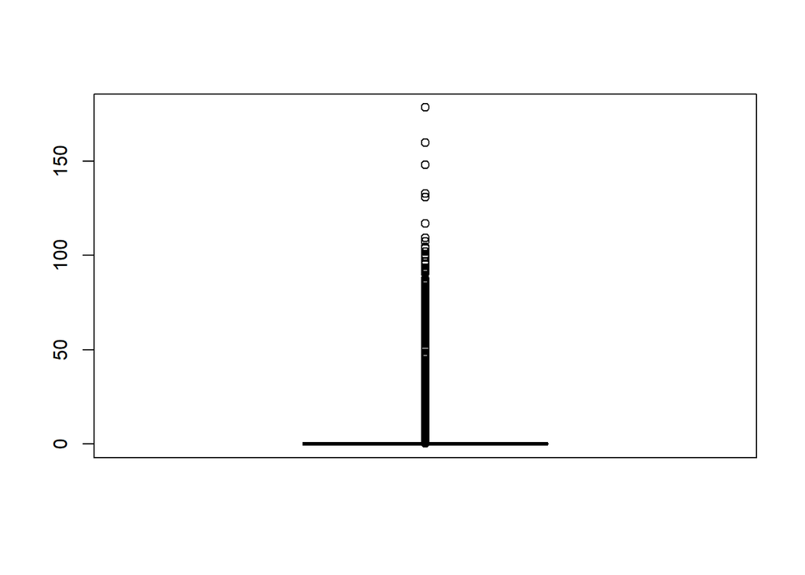

```r
boxplot(db2$강수량) # 일일 강수량은 약 80퍼센트가 1mm 미만으로 조정이 필요함
```

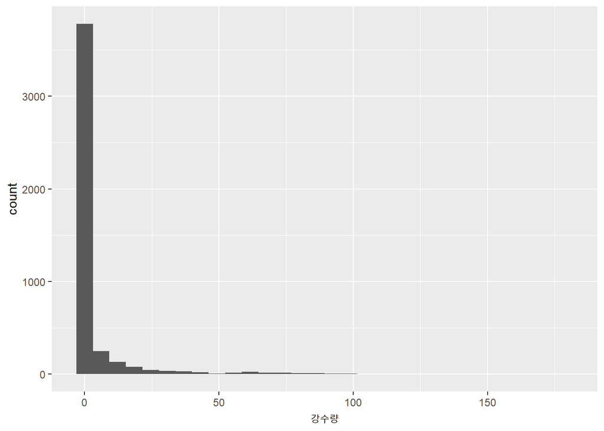

```r
db2 %>%
  ggplot2::ggplot(mapping = aes(x = 강수량)) +
  geom_histogram() # 히스토그램 결과 대부분이 0인 것을 확인
```

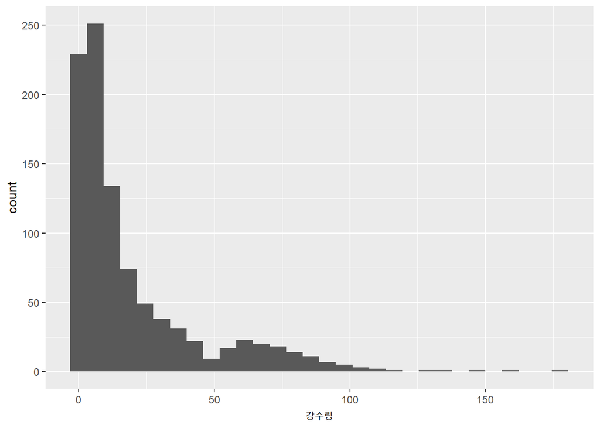

```r
# 0이 아닌 강수량 그래프

db2 %>%
  filter(강수량 >= 1) %>%
  ggplot2::ggplot(mapping = aes(x = 강수량)) +
  geom_histogram()
```

```r
db2 <- db2 %>%
  mutate(강수량수준 = ifelse(강수량 < 1 , "1mm미만",
                           ifelse(강수량 < 20 , "20mm미만", "20mm초과" )))


prop.table(table(db2$강수량수준)) # 강수량수준 테이블
```

```
##
##    1mm미만   20mm미만   20mm초과
## 0.78666371 0.14864865 0.06468764
```

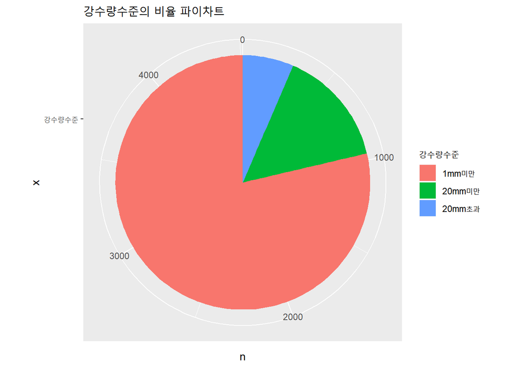

```r
db2 %>%
  dplyr::group_by(강수량수준) %>%
  dplyr::summarise(n = n()) %>% #최종적으로 갖고싶은 값, n() = 데이터의 개수를 세어준다.
  ggplot2::ggplot(mapping = aes(x= "강수량수준", y = n , fill = 강수량수준))+ #aes에 x축에 넣고싶은 값, y축에 넣고싶은 값 / x축과 y축
  geom_bar(stat = "identity")+
  coord_polar("y")+
 ggtitle("강수량수준의 비율 파이차트")
```

### 2-4. 최종 데이터 전처리

```r
# db - 전처리 전 데이터 셋 -> 모델 1에서 활용
# db2 - 전처리 후 데이터 셋 -> 그 외 모델에서 활용


# 전처리 전 데이터셋 분할 training:test=8:2
set.seed(seed = 1902)  # 프로젝트 년월

index <- sample(x = 1:2,
                size = nrow(x = db),
                replace = TRUE,
                prob = c(0.8, 0.2))

train0Set <- db[index == 1, ] # 전처리전db 기준 trainset


# 전처리 후 데이터셋 분할 training:test=8:2

set.seed(seed = 1902)  # 프로젝트 년월

index <- sample(x = 1:2,
                size = nrow(x = db2),
                replace = TRUE,
                prob = c(0.8, 0.2))


trainSet <- db2[index == 1, ] # 전처리후db 기준 trainset
testSet  <- db2[index == 2, ]


db_train <- trainSet
db_train0 <- train0Set
db_test  <- testSet

db2 <- db2[,-c(1,2)]
db <- db[,-c(1,2)]

db_train0 <- db_train[,-c(1,2)]

db_train <- db_train[,-c(1,2)]
db_test <- db_test[,-c(1,2)]

str(db2)
```

```
## 'data.frame':    4514 obs. of  17 variables:
##  $ 지역          : Factor w/ 23 levels "강남구","강동구",..: 1 2 3 5 6 7 8 9 10 11 ...
##  $ 대여건수      : int  235 114 82 363 162 74 86 30 215 130 ...
##  $ 지하철        : int  1494999 318430 130921 446626 607542 203126 458971 212206 422955 546867 ...
##  $ 평균기온      : num  -2.6 -2.3 -2.7 -2.2 -2.8 ...
##  $ 평균습도      : num  43.5 37.8 43.8 44.6 42 ...
##  $ 평균풍속      : num  1.1 1.3 0.9 1.1 1.8 ...
##  $ 강수량        : num  0.5 0 0 0 0 0 0 0 0 0 ...
##  $ 이산화질소농도: num  0.045 0.046 0.027 0.044 0.026 0.044 0.037 0.03 0.045 0.043 ...
##  $ 오존농도      : num  0.006 0.009 0.022 0.011 0.009 0.011 0.014 0.019 0.01 0.01 ...
##  $ 일산화탄소농도: num  0.6 0.8 0.5 0.7 0.6 0.7 0.7 0.6 0.6 0.7 ...
##  $ 아황산가스농도: num  0.006 0.005 0.004 0.005 0.007 0.005 0.007 0.005 0.007 0.004 ...
##  $ 미세먼지량    : int  39 44 31 41 42 37 39 39 36 40 ...
##  $ 초미세먼지량  : int  25 25 16 22 23 23 21 21 22 22 ...
##  $ 버스          : int  721145 242003 418709 235333 480253 328776 377779 298790 461745 477474 ...
##  $ Month         : num  8 10 9 28 9 9 9 9 19 8 ...
##  $ WeekDay       : Factor w/ 2 levels "0","1": 1 1 1 1 1 1 1 1 1 1 ...
##  $ 강수량수준    : chr  "1mm미만" "1mm미만" "1mm미만" "1mm미만" ...
```

```r
# 계수 표준화
db3 <- sapply(X = db2,
       FUN = function(x)
         {
         if((class(x) == "numeric"  | class(x) == "integer")) scale(x = x,
                                                                    center = min(x),
                                                                    scale = max(x) - min(x))
         else rep(x = NA_real_ ,times = length(x))
         }
       )
db3 %>% as.data.frame() %>% str(db3)
```

```
## 'data.frame':    4514 obs. of  17 variables:
##  $ 지역          : num  NA NA NA NA NA NA NA NA NA NA ...
##  $ 대여건수      : num  0.0375 0.0172 0.0119 0.0589 0.0253 ...
##  $ 지하철        : num  0.9244 0.1742 0.0546 0.2559 0.3585 ...
##  $ 평균기온      : num  0.177 0.184 0.175 0.186 0.173 ...
##  $ 평균습도      : num  0.417 0.357 0.42 0.428 0.401 ...
##  $ 평균풍속      : num  0.134 0.159 0.11 0.134 0.22 ...
##  $ 강수량        : num  0.0028 0 0 0 0 ...
##  $ 이산화질소농도: num  0.512 0.523 0.302 0.5 0.291 ...
##  $ 오존농도      : num  0.0833 0.125 0.3056 0.1528 0.125 ...
##  $ 일산화탄소농도: num  0.385 0.538 0.308 0.462 0.385 ...
##  $ 아황산가스농도: num  0.357 0.286 0.214 0.286 0.429 ...
##  $ 미세먼지량    : num  0.168 0.192 0.131 0.178 0.182 ...
##  $ 초미세먼지량  : num  0.0244 0.0244 0.0152 0.0213 0.0224 ...
##  $ 버스          : num  0.92 0.308 0.534 0.3 0.612 ...
##  $ Month         : num  0 0.0667 0.0333 0.6667 0.0333 ...
##  $ WeekDay       : num  NA NA NA NA NA NA NA NA NA NA ...
##  $ 강수량수준    : num  NA NA NA NA NA NA NA NA NA NA ...
```

```r
db3 <- db3 %>% as.data.frame()
db3$지역 <- db2$지역
db3$강수량수준 <- db2$강수량수준
db3$WeekDay <- db2$WeekDay

trainSet2 <- db3[index == 1, ]
testSet2  <- db3[index == 2, ]

db_train2 <- trainSet2
db_test2 <- testSet2
```

# 3. 회귀모델 설명

```r
temp_db <- db_train0
model_1 <- lm(대여건수 ~., data = temp_db)
summary(model_1)
```

```
##
## Call:
## lm(formula = 대여건수 ~ ., data = temp_db)
##
## Residuals:
##     Min      1Q  Median      3Q     Max
## -2527.0  -260.9     5.1   235.8  3378.1
##
## Coefficients:
##                         Estimate    Std. Error t value
## (Intercept)         -892.9280097   154.3860794  -5.784
## 지역강동구           133.4081079   108.3298731   1.231
## 지역강북구          -338.4650076   132.4910217  -2.555
## 지역관악구           308.5210398   134.9175910   2.287
## 지역광진구         -1114.3047289   123.9329840  -8.991
## 지역구로구            67.8273784    93.8879615   0.722
## 지역금천구           -38.5713788   129.9195372  -0.297
## 지역노원구           413.3072593    96.4075184   4.287
## 지역도봉구          -424.6451863   116.9864196  -3.630
## 지역동대문구        -993.0105885   113.9950013  -8.711
## 지역동작구            -2.3642436    95.7966690  -0.025
## 지역마포구          -484.8226695   110.3606925  -4.393
## 지역서대문구       -1818.4904015   162.7940884 -11.170
## 지역서초구           428.1184756    99.5563904   4.300
## 지역성동구         -1327.9299795   129.8558698 -10.226
## 지역성북구            84.5136203   116.8047333   0.724
## 지역송파구          1045.5849194    89.3424373  11.703
## 지역양천구         -1149.2374759   131.3084008  -8.752
## 지역영등포구         -65.0812729   126.3006217  -0.515
## 지역용산구         -1307.6756030   118.1001409 -11.073
## 지역은평구          -885.5501746   112.6102362  -7.864
## 지역중구           -2549.1000912   110.2646149 -23.118
## 지역중랑구           -14.6157220   115.2108524  -0.127
## 지하철                 0.0005831     0.0001334   4.372
## 평균기온              17.6784512     1.2401932  14.255
## 평균습도              -1.4715053     0.8513755  -1.728
## 평균풍속             -64.2332840    15.5783133  -4.123
## 강수량                -7.7480291     1.2049686  -6.430
## 이산화질소농도      3991.7940561  1336.8225340   2.986
## 오존농도            5350.7622248   966.8905862   5.534
```

[output cut: 40 more lines]

```
## 일산화탄소농도                 0.014438 *
## 아황산가스농도                 0.620775
## 미세먼지량         0.000000000001166295 ***
## 초미세먼지량                   0.008848 **
## 버스                           0.539108
## Month              < 0.0000000000000002 ***
## WeekDay1                       0.003735 **
## 강수량수준20mm미만 < 0.0000000000000002 ***
## 강수량수준20mm초과 0.000000000000000915 ***
## ---
## Signif. codes:  0 '***' 0.001 '**' 0.01 '*' 0.05 '.' 0.1 ' ' 1
##
## Residual standard error: 487.9 on 3532 degrees of freedom
## Multiple R-squared:  0.7741, Adjusted R-squared:  0.7717
## F-statistic: 318.6 on 38 and 3532 DF,  p-value: < 0.00000000000000022
```

```r
car::vif(model_1)
```

```
##                       GVIF Df GVIF^(1/(2*Df))
## 지역           9223.161515 22        1.230583
## 지하철           22.528043  1        4.746372
## 평균기온          2.265059  1        1.505011
## 평균습도          2.590182  1        1.609404
## 평균풍속          2.333559  1        1.527599
## 강수량            4.237588  1        2.058540
## 이산화질소농도    4.386691  1        2.094443
## 오존농도          2.085624  1        1.444169
## 일산화탄소농도    3.563211  1        1.887647
## 아황산가스농도    2.330648  1        1.526646
## 미세먼지량        2.692321  1        1.640829
## 초미세먼지량      1.582635  1        1.258028
## 버스             18.235654  1        4.270323
## Month            14.833687  1        3.851453
## WeekDay           3.285618  1        1.812627
## 강수량수준        5.531906  2        1.533623
```

```r
#다중공선성 문제 발생
```

### 3-2. model_2 전처리 이후 변형 회귀모형

```r
temp_db <- db_train
model_2 <- lm(대여건수 ~., data = db_train)


summary(model_2)
```

```
##
## Call:
## lm(formula = 대여건수 ~ ., data = db_train)
##
## Residuals:
##     Min      1Q  Median      3Q     Max
## -2527.0  -260.9     5.1   235.8  3378.1
##
## Coefficients:
##                         Estimate    Std. Error t value
## (Intercept)         -892.9280097   154.3860794  -5.784
## 지역강동구           133.4081079   108.3298731   1.231
## 지역강북구          -338.4650076   132.4910217  -2.555
## 지역관악구           308.5210398   134.9175910   2.287
## 지역광진구         -1114.3047289   123.9329840  -8.991
## 지역구로구            67.8273784    93.8879615   0.722
## 지역금천구           -38.5713788   129.9195372  -0.297
## 지역노원구           413.3072593    96.4075184   4.287
## 지역도봉구          -424.6451863   116.9864196  -3.630
## 지역동대문구        -993.0105885   113.9950013  -8.711
## 지역동작구            -2.3642436    95.7966690  -0.025
## 지역마포구          -484.8226695   110.3606925  -4.393
## 지역서대문구       -1818.4904015   162.7940884 -11.170
## 지역서초구           428.1184756    99.5563904   4.300
## 지역성동구         -1327.9299795   129.8558698 -10.226
## 지역성북구            84.5136203   116.8047333   0.724
## 지역송파구          1045.5849194    89.3424373  11.703
## 지역양천구         -1149.2374759   131.3084008  -8.752
## 지역영등포구         -65.0812729   126.3006217  -0.515
## 지역용산구         -1307.6756030   118.1001409 -11.073
## 지역은평구          -885.5501746   112.6102362  -7.864
## 지역중구           -2549.1000912   110.2646149 -23.118
## 지역중랑구           -14.6157220   115.2108524  -0.127
## 지하철                 0.0005831     0.0001334   4.372
## 평균기온              17.6784512     1.2401932  14.255
## 평균습도              -1.4715053     0.8513755  -1.728
## 평균풍속             -64.2332840    15.5783133  -4.123
## 강수량                -7.7480291     1.2049686  -6.430
## 이산화질소농도      3991.7940561  1336.8225340   2.986
## 오존농도            5350.7622248   966.8905862   5.534
```

[output cut: 40 more lines]

```
## 일산화탄소농도                 0.014438 *
## 아황산가스농도                 0.620775
## 미세먼지량         0.000000000001166295 ***
## 초미세먼지량                   0.008848 **
## 버스                           0.539108
## Month              < 0.0000000000000002 ***
## WeekDay1                       0.003735 **
## 강수량수준20mm미만 < 0.0000000000000002 ***
## 강수량수준20mm초과 0.000000000000000915 ***
## ---
## Signif. codes:  0 '***' 0.001 '**' 0.01 '*' 0.05 '.' 0.1 ' ' 1
##
## Residual standard error: 487.9 on 3532 degrees of freedom
## Multiple R-squared:  0.7741, Adjusted R-squared:  0.7717
## F-statistic: 318.6 on 38 and 3532 DF,  p-value: < 0.00000000000000022
```

```r
car::vif(model_2)
```

```
##                       GVIF Df GVIF^(1/(2*Df))
## 지역           9223.161515 22        1.230583
## 지하철           22.528043  1        4.746372
## 평균기온          2.265059  1        1.505011
## 평균습도          2.590182  1        1.609404
## 평균풍속          2.333559  1        1.527599
## 강수량            4.237588  1        2.058540
## 이산화질소농도    4.386691  1        2.094443
## 오존농도          2.085624  1        1.444169
## 일산화탄소농도    3.563211  1        1.887647
## 아황산가스농도    2.330648  1        1.526646
## 미세먼지량        2.692321  1        1.640829
## 초미세먼지량      1.582635  1        1.258028
## 버스             18.235654  1        4.270323
## Month            14.833687  1        3.851453
## WeekDay           3.285618  1        1.812627
## 강수량수준        5.531906  2        1.533623
```

```r
#다중공선성 문제 발생
```

```r
forward_model <- step(model_2, direction = "forward")
```

```
## Start:  AIC=44248.94
## 대여건수 ~ 지역 + 지하철 + 평균기온 + 평균습도 + 평균풍속 + 강수량 +
##     이산화질소농도 + 오존농도 + 일산화탄소농도 + 아황산가스농도 +
##     미세먼지량 + 초미세먼지량 + 버스 + Month + WeekDay + 강수량수준
```

```r
backward_model <- step(model_2, direction = "backward")
```

```
## Start:  AIC=44248.94
## 대여건수 ~ 지역 + 지하철 + 평균기온 + 평균습도 + 평균풍속 + 강수량 +
##     이산화질소농도 + 오존농도 + 일산화탄소농도 + 아황산가스농도 +
##     미세먼지량 + 초미세먼지량 + 버스 + Month + WeekDay + 강수량수준
##
##                  Df Sum of Sq        RSS   AIC
## - 아황산가스농도  1     58285  840928410 44247
## - 버스            1     89817  840959942 44247
## <none>                         840870125 44249
## - 평균습도        1    711196  841581321 44250
## - 일산화탄소농도  1   1425977  842296101 44253
## - 초미세먼지량    1   1633399  842503523 44254
## - WeekDay         1   2004492  842874617 44255
## - 이산화질소농도  1   2122741  842992865 44256
## - 평균풍속        1   4047507  844917632 44264
## - 지하철          1   4550929  845421054 44266
## - 오존농도        1   7290963  848161087 44278
## - 강수량          1   9843266  850713391 44288
## - 미세먼지량      1  12120912  852991037 44298
## - 평균기온        1  48374664  889244789 44447
## - 강수량수준      2  49353511  890223636 44449
## - Month           1 255305367 1096175491 45194
## - 지역           22 989609182 1830479306 46983
##
## Step:  AIC=44247.19
## 대여건수 ~ 지역 + 지하철 + 평균기온 + 평균습도 + 평균풍속 + 강수량 +
##     이산화질소농도 + 오존농도 + 일산화탄소농도 + 미세먼지량 +
##     초미세먼지량 + 버스 + Month + WeekDay + 강수량수준
##
##                  Df Sum of Sq        RSS   AIC
## - 버스            1     83839  841012249 44246
## <none>                         840928410 44247
## - 평균습도        1    691795  841620205 44248
## - 일산화탄소농도  1   1473342  842401752 44251
## - 초미세먼지량    1   1656510  842584920 44252
## - WeekDay         1   1992499  842920909 44254
## - 이산화질소농도  1   2071899  843000310 44254
## - 평균풍속        1   4010101  844938511 44262
## - 지하철          1   4586340  845514750 44265
## - 오존농도        1   7357780  848286190 44276
```

[output cut: 13 more lines]

```
## <none>                          841012249 44246
## - 평균습도        1     695424  841707673 44246
## - 일산화탄소농도  1    1534217  842546466 44250
## - 초미세먼지량    1    1680234  842692483 44251
## - 이산화질소농도  1    2195274  843207523 44253
## - WeekDay         1    2544255  843556504 44254
## - 평균풍속        1    3931655  844943904 44260
## - 오존농도        1    7322793  848335041 44274
## - 강수량          1    9880412  850892660 44285
## - 지하철          1   10740474  851752723 44289
## - 미세먼지량      1   12678193  853690442 44297
## - 강수량수준      2   49322570  890334819 44445
## - 평균기온        1   49015999  890028248 44446
## - Month           1  265341759 1106354008 45223
## - 지역           22 1079261447 1920273696 47150
```

```r
both_model <- step(model_2, direction = "both")
```

```
## Start:  AIC=44248.94
## 대여건수 ~ 지역 + 지하철 + 평균기온 + 평균습도 + 평균풍속 + 강수량 +
##     이산화질소농도 + 오존농도 + 일산화탄소농도 + 아황산가스농도 +
##     미세먼지량 + 초미세먼지량 + 버스 + Month + WeekDay + 강수량수준
##
##                  Df Sum of Sq        RSS   AIC
## - 아황산가스농도  1     58285  840928410 44247
## - 버스            1     89817  840959942 44247
## <none>                         840870125 44249
## - 평균습도        1    711196  841581321 44250
## - 일산화탄소농도  1   1425977  842296101 44253
## - 초미세먼지량    1   1633399  842503523 44254
## - WeekDay         1   2004492  842874617 44255
## - 이산화질소농도  1   2122741  842992865 44256
## - 평균풍속        1   4047507  844917632 44264
## - 지하철          1   4550929  845421054 44266
## - 오존농도        1   7290963  848161087 44278
## - 강수량          1   9843266  850713391 44288
## - 미세먼지량      1  12120912  852991037 44298
## - 평균기온        1  48374664  889244789 44447
## - 강수량수준      2  49353511  890223636 44449
## - Month           1 255305367 1096175491 45194
## - 지역           22 989609182 1830479306 46983
##
## Step:  AIC=44247.19
## 대여건수 ~ 지역 + 지하철 + 평균기온 + 평균습도 + 평균풍속 + 강수량 +
##     이산화질소농도 + 오존농도 + 일산화탄소농도 + 미세먼지량 +
##     초미세먼지량 + 버스 + Month + WeekDay + 강수량수준
##
##                  Df Sum of Sq        RSS   AIC
## - 버스            1     83839  841012249 44246
## <none>                         840928410 44247
## - 평균습도        1    691795  841620205 44248
## + 아황산가스농도  1     58285  840870125 44249
## - 일산화탄소농도  1   1473342  842401752 44251
## - 초미세먼지량    1   1656510  842584920 44252
## - WeekDay         1   1992499  842920909 44254
## - 이산화질소농도  1   2071899  843000310 44254
## - 평균풍속        1   4010101  844938511 44262
## - 지하철          1   4586340  845514750 44265
```

[output cut: 16 more lines]

```
## + 버스            1      83839  840928410 44247
## + 아황산가스농도  1      52307  840959942 44247
## - 일산화탄소농도  1    1534217  842546466 44250
## - 초미세먼지량    1    1680234  842692483 44251
## - 이산화질소농도  1    2195274  843207523 44253
## - WeekDay         1    2544255  843556504 44254
## - 평균풍속        1    3931655  844943904 44260
## - 오존농도        1    7322793  848335041 44274
## - 강수량          1    9880412  850892660 44285
## - 지하철          1   10740474  851752723 44289
## - 미세먼지량      1   12678193  853690442 44297
## - 강수량수준      2   49322570  890334819 44445
## - 평균기온        1   49015999  890028248 44446
## - Month           1  265341759 1106354008 45223
## - 지역           22 1079261447 1920273696 47150
```

```r
summary(both_model)
```

```
##
## Call:
## lm(formula = 대여건수 ~ 지역 + 지하철 + 평균기온 + 평균습도 +
##     평균풍속 + 강수량 + 이산화질소농도 + 오존농도 + 일산화탄소농도 +
##     미세먼지량 + 초미세먼지량 + Month + WeekDay + 강수량수준,
##     data = db_train)
##
## Residuals:
##     Min      1Q  Median      3Q     Max
## -2529.6  -263.2     5.6   236.4  3379.5
##
## Coefficients:
##                          Estimate     Std. Error t value
## (Intercept)         -898.22488524   146.30501721  -6.139
## 지역강동구           133.63182178   108.12107122   1.236
## 지역강북구          -297.60839684   119.92411758  -2.482
## 지역관악구           365.15836090   105.23829284   3.470
## 지역광진구         -1131.84578228   121.48719214  -9.317
## 지역구로구            83.96840643    91.28256404   0.920
## 지역금천구           -17.48734876   126.80146467  -0.138
## 지역노원구           423.76267983    95.06706639   4.458
## 지역도봉구          -409.62156559   115.04817048  -3.560
## 지역동대문구        -980.40304887   108.44358668  -9.041
## 지역동작구            21.27136574    90.49486729   0.235
## 지역마포구          -487.53843296   110.05203581  -4.430
## 지역서대문구       -1774.21666237   147.49830570 -12.029
## 지역서초구           467.23454558    83.12310605   5.621
## 지역성동구         -1343.35024388   128.26960041 -10.473
## 지역성북구           127.15692435   100.50619308   1.265
## 지역송파구          1067.28368094    84.48657652  12.633
## 지역양천구         -1127.03601880   127.68364343  -8.827
## 지역영등포구         -57.28977836   124.37407929  -0.461
## 지역용산구         -1295.03312006   116.93779982 -11.075
## 지역은평구          -865.61673429   108.84183862  -7.953
## 지역중구           -2576.61116428    99.00442499 -26.025
## 지역중랑구            -6.50996717   113.53852906  -0.057
## 지하철                 0.00064040     0.00009533   6.718
## 평균기온              17.70688506     1.23378966  14.352
## 평균습도              -1.45302890     0.84999654  -1.709
## 평균풍속             -62.86276900    15.46584668  -4.065
```

[output cut: 39 more lines]

```
## 이산화질소농도                 0.002405 **
## 오존농도           0.000000031167664896 ***
## 일산화탄소농도                 0.011157 *
## 미세먼지량         0.000000000000356420 ***
## 초미세먼지량                   0.007916 **
## Month              < 0.0000000000000002 ***
## WeekDay1                       0.001087 **
## 강수량수준20mm미만 < 0.0000000000000002 ***
## 강수량수준20mm초과 0.000000000000000905 ***
## ---
## Signif. codes:  0 '***' 0.001 '**' 0.01 '*' 0.05 '.' 0.1 ' ' 1
##
## Residual standard error: 487.8 on 3534 degrees of freedom
## Multiple R-squared:  0.7741, Adjusted R-squared:  0.7718
## F-statistic: 336.4 on 36 and 3534 DF,  p-value: < 0.00000000000000022
```

```r
car::vif(both_model)
```

```
##                      GVIF Df GVIF^(1/(2*Df))
## 지역           551.296127 22        1.154261
## 지하철          11.513200  1        3.393111
## 평균기온         2.242619  1        1.497538
## 평균습도         2.582824  1        1.607117
## 평균풍속         2.300900  1        1.516872
## 강수량           4.235777  1        2.058100
## 이산화질소농도   4.281200  1        2.069106
## 오존농도         2.080706  1        1.442465
## 일산화탄소농도   3.526648  1        1.877937
## 미세먼지량       2.626875  1        1.620764
## 초미세먼지량     1.579386  1        1.256736
## Month           14.380807  1        3.792204
## WeekDay          1.941727  1        1.393459
## 강수량수준       5.500460  2        1.531439
```

```r
model_3<- lm(formula = 대여건수 ~ 지역 + 평균기온 + 평균습도 +
    평균풍속 + 강수량 + 이산화질소농도 + 오존농도 + 일산화탄소농도 +
    미세먼지량 + 초미세먼지량 + Month + WeekDay + 강수량수준,
    data = db_train)

summary(model_3)
```

```
##
## Call:
## lm(formula = 대여건수 ~ 지역 + 평균기온 + 평균습도 + 평균풍속 +
##     강수량 + 이산화질소농도 + 오존농도 + 일산화탄소농도 + 미세먼지량 +
##     초미세먼지량 + Month + WeekDay + 강수량수준, data = db_train)
##
## Residuals:
##     Min      1Q  Median      3Q     Max
## -2525.1  -264.1     9.4   237.7  3339.2
##
## Coefficients:
##                      Estimate Std. Error t value             Pr(>|t|)
## (Intercept)         -136.1276    92.9681  -1.464             0.143218
## 지역강동구          -488.4830    56.1576  -8.698 < 0.0000000000000002 ***
## 지역강북구         -1008.9760    56.6473 -17.812 < 0.0000000000000002 ***
## 지역관악구          -218.9829    59.6533  -3.671             0.000245 ***
## 지역광진구         -1690.7633    89.0807 -18.980 < 0.0000000000000002 ***
## 지역구로구          -385.2667    59.1358  -6.515 0.000000000083002159 ***
## 지역금천구          -718.5133    72.4886  -9.912 < 0.0000000000000002 ***
## 지역노원구           -90.8626    56.6503  -1.604             0.108821
## 지역도봉구         -1074.4524    59.0393 -18.199 < 0.0000000000000002 ***
## 지역동대문구       -1558.4382    66.4167 -23.465 < 0.0000000000000002 ***
## 지역동작구          -462.2702    55.1932  -8.376 < 0.0000000000000002 ***
## 지역마포구          -886.1452    93.2643  -9.501 < 0.0000000000000002 ***
## 지역서대문구       -2530.2073    95.9480 -26.371 < 0.0000000000000002 ***
## 지역서초구            50.7630    55.7191   0.911             0.362330
## 지역성동구         -1960.2901    90.1105 -21.754 < 0.0000000000000002 ***
## 지역성북구          -437.5220    55.4468  -7.891 0.000000000000003970 ***
## 지역송파구           660.3409    59.2623  11.143 < 0.0000000000000002 ***
## 지역양천구         -1860.6017    66.5933 -27.940 < 0.0000000000000002 ***
## 지역영등포구        -543.4790   101.7799  -5.340 0.000000098946326913 ***
## 지역용산구         -1915.9155    72.0909 -26.576 < 0.0000000000000002 ***
## 지역은평구         -1450.7313    65.6816 -22.087 < 0.0000000000000002 ***
## 지역중구           -2846.5022    91.0503 -31.263 < 0.0000000000000002 ***
## 지역중랑구          -673.3070    55.4753 -12.137 < 0.0000000000000002 ***
## 평균기온              17.3097     1.2400  13.959 < 0.0000000000000002 ***
## 평균습도              -1.1304     0.8539  -1.324             0.185680
## 평균풍속             -53.0889    15.4931  -3.427             0.000618 ***
## 강수량                -7.7790     1.2120  -6.419 0.000000000155892199 ***
## 이산화질소농도      5221.9864  1316.1518   3.968 0.000074035388812847 ***
## 오존농도            5560.1801   971.0858   5.726 0.000000011157576147 ***
## 일산화탄소농도      -236.4213    80.7534  -2.928             0.003437 **
## 미세먼지량            -4.2674     0.5923  -7.205 0.000000000000704746 ***
## 초미세먼지량          -1.3053     0.4796  -2.722             0.006529 **
## Month                117.2487     3.4557  33.929 < 0.0000000000000002 ***
## WeekDay1             -28.5718    18.8216  -1.518             0.129097
## 강수량수준20mm미만  -404.2706    28.2434 -14.314 < 0.0000000000000002 ***
## 강수량수준20mm초과  -588.1121    71.3841  -8.239 0.000000000000000242 ***
## ---
## Signif. codes:  0 '***' 0.001 '**' 0.01 '*' 0.05 '.' 0.1 ' ' 1
##
## Residual standard error: 490.9 on 3535 degrees of freedom
## Multiple R-squared:  0.7712, Adjusted R-squared:  0.769
## F-statistic: 340.5 on 35 and 3535 DF,  p-value: < 0.00000000000000022
```

```r
car::vif(model_3)
```

```
##                     GVIF Df GVIF^(1/(2*Df))
## 지역           56.474384 22        1.096011
## 평균기온        2.237468  1        1.495817
## 평균습도        2.574577  1        1.604549
## 평균풍속        2.280539  1        1.510145
## 강수량          4.235756  1        2.058095
## 이산화질소농도  4.201319  1        2.049712
## 오존농도        2.078646  1        1.441751
## 일산화탄소농도  3.514047  1        1.874579
## 미세먼지량      2.626735  1        1.620721
## 초미세먼지량    1.579155  1        1.256645
## Month          14.262924  1        3.776629
## WeekDay         1.101198  1        1.049380
## 강수량수준      5.492445  2        1.530881
```

```r
car::durbinWatsonTest(model_3)
```

```
##  lag Autocorrelation D-W Statistic p-value
##    1       0.3369785      1.325873       0
##  Alternative hypothesis: rho != 0
```

```r
sort(lm.beta::lm.beta(model_3)$standardized, decreasing = TRUE)
```

```
##              Month           평균기온         지역송파구
##         1.03081819         0.16797362         0.12508413
##           오존농도     이산화질소농도         지역서초구
##         0.06640970         0.06542331         0.01022344
##        (Intercept)           WeekDay1           평균습도
##         0.00000000        -0.01281511        -0.01708678
##         지역노원구       초미세먼지량         지역관악구
##        -0.01802063        -0.02751320        -0.03849214
##           평균풍속     일산화탄소농도         지역구로구
##        -0.04162885        -0.04415092        -0.07664738
##         지역성북구         미세먼지량         지역금천구
##        -0.09123902        -0.09394378        -0.09547885
##         지역동작구       지역영등포구         지역강동구
##        -0.09613010        -0.09820094        -0.09837825
##             강수량         지역중랑구 강수량수준20mm미만
##        -0.10627008        -0.13843006        -0.13987468
## 강수량수준20mm초과         지역마포구         지역강북구
##        -0.14081492        -0.18323601        -0.21040768
##         지역도봉구         지역은평구       지역동대문구
##        -0.22343471        -0.30421438        -0.33999970
##         지역용산구         지역광진구         지역양천구
##        -0.35143363        -0.35940020        -0.40075397
##         지역성동구       지역서대문구           지역중구
##        -0.40186603        -0.47762331        -0.59026915
```

```r
gvlma::gvlma(model_3)
```

```
##
## Call:
## lm(formula = 대여건수 ~ 지역 + 평균기온 + 평균습도 + 평균풍속 +
##     강수량 + 이산화질소농도 + 오존농도 + 일산화탄소농도 + 미세먼지량 +
##     초미세먼지량 + Month + WeekDay + 강수량수준, data = db_train)
##
## Coefficients:
##        (Intercept)          지역강동구          지역강북구
##           -136.128            -488.483           -1008.976
##         지역관악구          지역광진구          지역구로구
##           -218.983           -1690.763            -385.267
##         지역금천구          지역노원구          지역도봉구
##           -718.513             -90.863           -1074.452
##       지역동대문구          지역동작구          지역마포구
##          -1558.438            -462.270            -886.145
##       지역서대문구          지역서초구          지역성동구
##          -2530.207              50.763           -1960.290
##         지역성북구          지역송파구          지역양천구
##           -437.522             660.341           -1860.602
##       지역영등포구          지역용산구          지역은평구
##           -543.479           -1915.916           -1450.731
##           지역중구          지역중랑구            평균기온
##          -2846.502            -673.307              17.310
##           평균습도            평균풍속              강수량
##             -1.130             -53.089              -7.779
##     이산화질소농도            오존농도      일산화탄소농도
##           5221.986            5560.180            -236.421
##         미세먼지량        초미세먼지량               Month
##             -4.267              -1.305             117.249
##           WeekDay1  강수량수준20mm미만  강수량수준20mm초과
##            -28.572            -404.271            -588.112
##
##
## ASSESSMENT OF THE LINEAR MODEL ASSUMPTIONS
## USING THE GLOBAL TEST ON 4 DEGREES-OF-FREEDOM:
## Level of Significance =  0.05
##
## Call:
##  gvlma::gvlma(x = model_3)
##
##                      Value              p-value                   Decision
## Global Stat        3257.90 0.000000000000000000 Assumptions NOT satisfied!
## Skewness             61.12 0.000000000000005329 Assumptions NOT satisfied!
## Kurtosis           2276.33 0.000000000000000000 Assumptions NOT satisfied!
## Link Function       841.90 0.000000000000000000 Assumptions NOT satisfied!
## Heteroscedasticity   78.54 0.000000000000000000 Assumptions NOT satisfied!
```

```r
####### Error에 대한 전체적인 가정은 만족하지 않았다
```

# 4. Overfitting Solution_A

### 4-1. outlier관측이 많아서 overfitting 될 가능성이 많다.

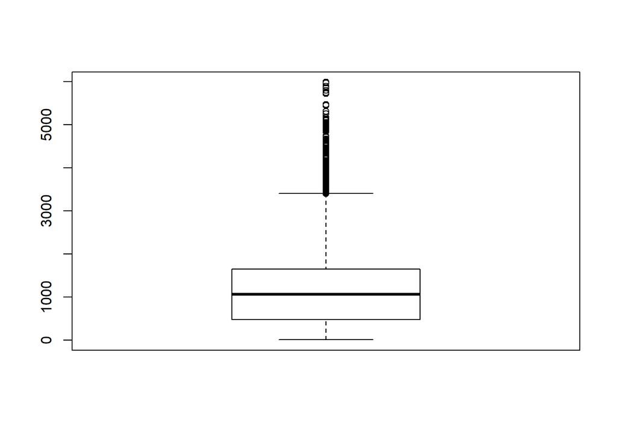

```r
boxplot(db2$대여건수)
```

### 4-2. cook’s distance * **큰 잔차 ( 이상치 ) 및 / 또는 높은 레버리지를 가진 데이터 포인트 는 회귀의 결과와 정확성을 왜곡시킬 수 있다. 쿡의 거리가 큰 포인트는 분석에서 면밀한 검사를 되받을만한 것으로 간주된다.**

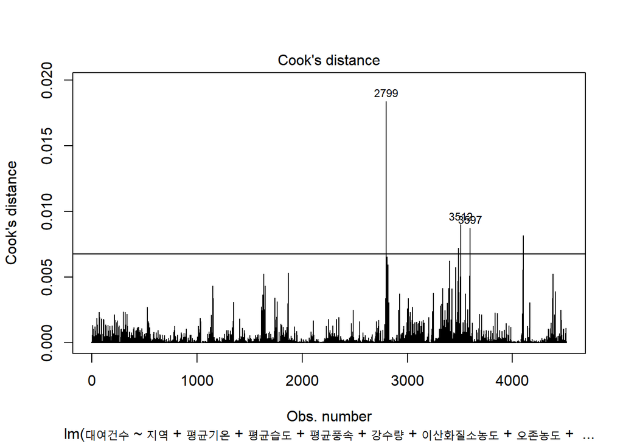

```r
model_4<- lm(formula = 대여건수 ~ 지역 + 평균기온 + 평균습도 +
    평균풍속 + 강수량 + 이산화질소농도 + 오존농도 + 일산화탄소농도 +
    미세먼지량 + 초미세먼지량 + Month + WeekDay + 강수량수준, data = db2[-c(2325), ])
plot(model_4, which = 4, pch="*")
abline(h = 10*mean(cooks.distance(model_3), col = "red"))
```

# 5. Overfitting Solution_B (RIDGE, LASSO TEST)

### 5-1. 기존 모델 RMSE

```r
predictions <- predict(model_3, db_test)
original <- rmse(db_test$대여건수, predictions)
original <- round(original, digits = 1)
original
```

```
## [1] 507.1
```

### 5-2. RIDGE, LASSO 모델을 위한 데이터 준비

```r
ridge_lasso_train_x <- model.matrix(대여건수 ~ 지역 + 평균기온 + 평균습도 +
                                    평균풍속 + 강수량 + 이산화질소농도 + 오존농도 + 일산화탄소농도 +
                                    미세먼지량 + 초미세먼지량 + Month + WeekDay + 강수량수준,
                                    data = db_train)[,-1]
ridge_lasso_train_y <- db_train$대여건수

ridge_lasso_test_x <- model.matrix(대여건수 ~ 지역 + 평균기온 + 평균습도 +
                                   평균풍속 + 강수량 + 이산화질소농도 + 오존농도 + 일산화탄소농도 +
                                   미세먼지량 + 초미세먼지량 + Month + WeekDay + 강수량수준,
                                    data = db_test)[,-1]
ridge_lasso_test_y <- db_test$대여건수

ridge_lasso_train_x_nor <- model.matrix(대여건수 ~ 지역 + 평균기온 + 평균습도 +
                                        평균풍속 + 강수량 + 이산화질소농도 + 오존농도 + 일산화탄소농도 +
                                        미세먼지량 + 초미세먼지량 + Month + WeekDay + 강수량수준,
                                        data = db_train2)[,-1]
ridge_lasso_train_y_nor <- db_train2$대여건수

ridge_lasso_test_x_nor <- model.matrix(대여건수 ~ 지역 + 평균기온 + 평균습도 +
                                       평균풍속 + 강수량 + 이산화질소농도 + 오존농도 + 일산화탄소농도 +
                                       미세먼지량 + 초미세먼지량 + Month + WeekDay + 강수량수준,
                                       data = db_test2)[,-1]
ridge_lasso_test_y_nor <- db_test2$대여건수
```

### 5-3. RIDGE

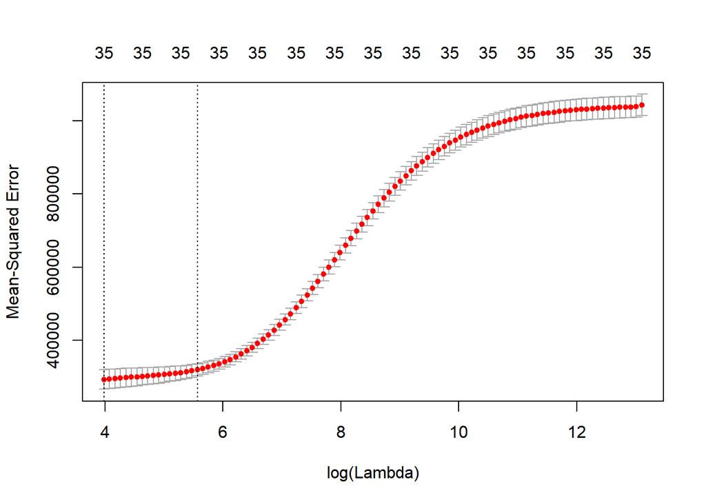

```r
# lambda 생성, 10^-2에서 10^10까지의 수를 100등분하여 만든 벡터
grid <- 10^seq(10, -2, length = 100)
ridge.mod <- glmnet(ridge_lasso_train_x, ridge_lasso_train_y, alpha = 0, lambda = grid, thresh = 1e-12)

set.seed(1)
# cross validation을 이용하여 람다 선택
cv.out_ridge <- cv.glmnet(ridge_lasso_train_x, ridge_lasso_train_y, alpha = 0)
plot(cv.out_ridge)
```

```r
# MSE가 최소가 되는 람다
bestlam_ridge <- cv.out_ridge$lambda.min
bestlam_ridge
```

```
## [1] 53.81032
```

```r
ridge.pred <- predict(ridge.mod, s = bestlam_ridge, newx = ridge_lasso_test_x)
ridge <- rmse(ridge_lasso_test_y, ridge.pred)
ridge <- round(ridge, digits = 1)
ridge
```

```
## [1] 523.2
```

### 5-4. LASSO

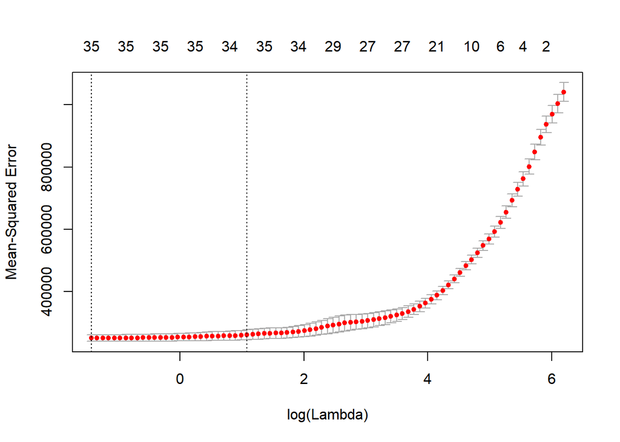

```r
lasso.mod <- glmnet(ridge_lasso_train_x, ridge_lasso_train_y, alpha = 1, lambda = grid)

set.seed(1)
cv.out_lasso <- cv.glmnet(ridge_lasso_train_x, ridge_lasso_train_y, alpha = 1)
plot(cv.out_lasso)
```

```r
bestlam_lasso <- cv.out_lasso$lambda.min
bestlam_lasso
```

```
## [1] 0.2384132
```

```r
lasso.pred <- predict(lasso.mod, s = bestlam_lasso, newx = ridge_lasso_test_x)
lasso <- rmse(ridge_lasso_test_y, lasso.pred)
lasso <- round(lasso, digits = 1)
lasso
```

```
## [1] 507
```

### 5-5. rmse 시각화

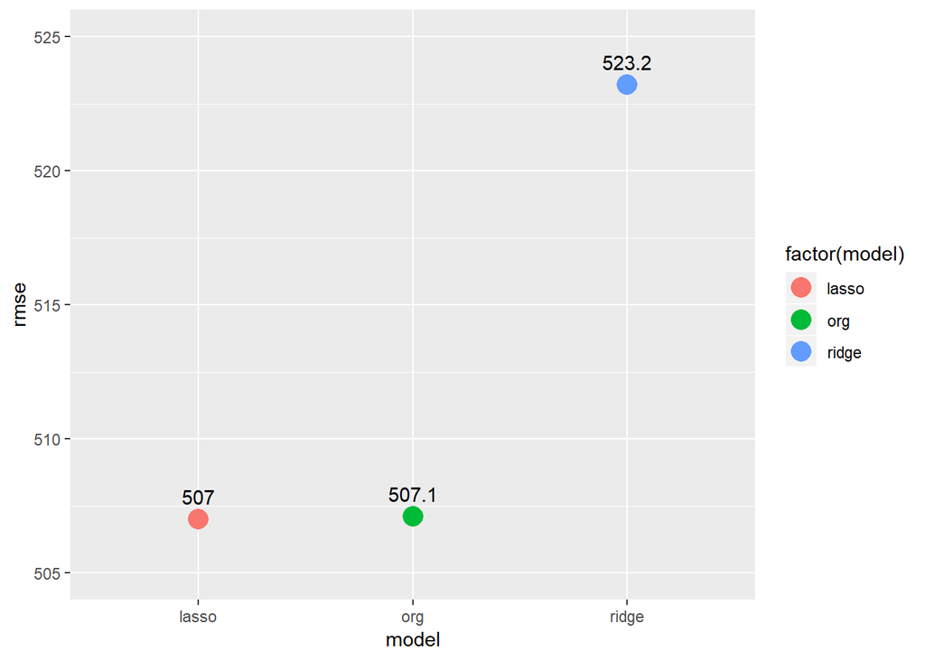

```r
df <- data.frame(c("org", "ridge", "lasso"), c(original, ridge, lasso))
colnames(df) <- c("model", "rmse")
df %>%
  ggplot2::ggplot(mapping = aes(x = model, y = rmse)) +
  geom_point(aes(colour = factor(model)), size = 5) +
  geom_text(aes(label = rmse), vjust = -1)  +
  ylim(505, 525)
```

### 5-6. norm, lamda에 따른 회귀계수

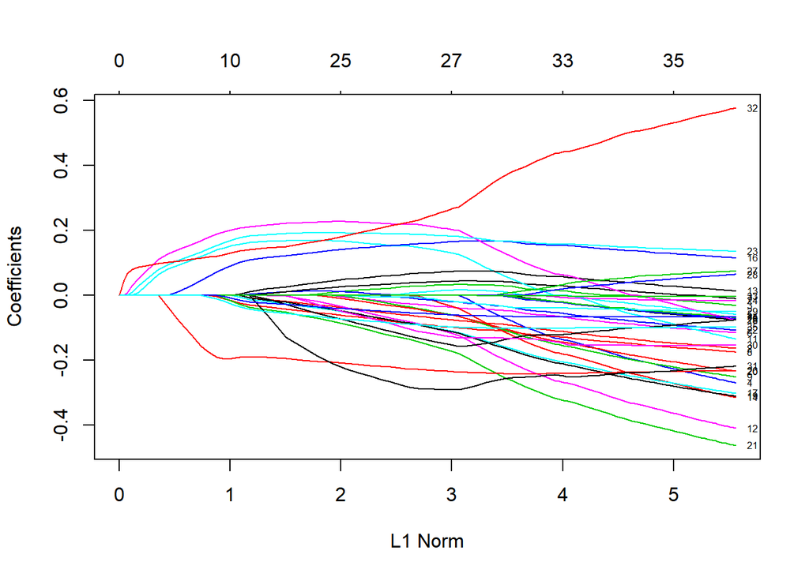

```r
cv.out_lasso_nor <- cv.glmnet(ridge_lasso_train_x_nor, ridge_lasso_train_y_nor, alpha = 1)
plot(cv.out_lasso_nor$glmnet.fit, xvar="norm", label=TRUE)
```

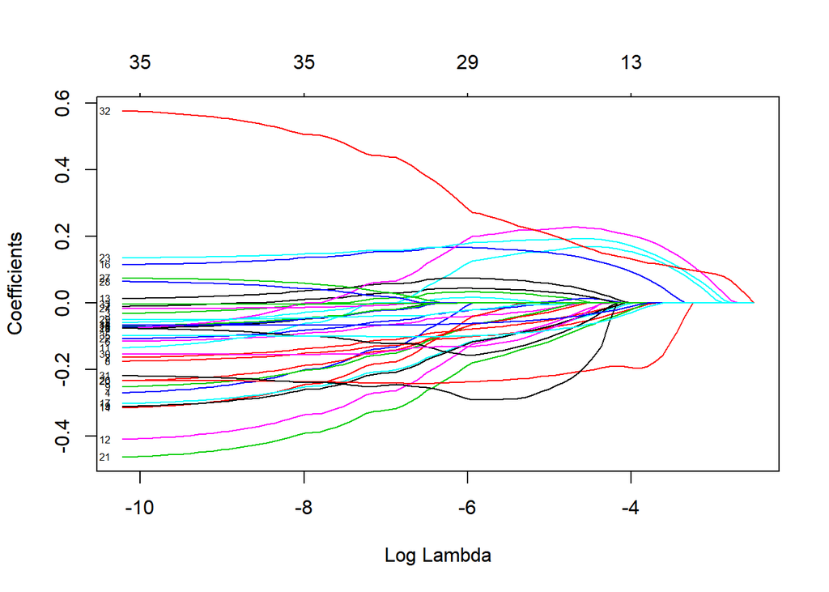

```r
plot(cv.out_lasso_nor$glmnet.fit, xvar="lambda", label=TRUE)
```

### 5-7. 선택된 lasso 계수

```r
out <- glmnet(ridge_lasso_train_x, ridge_lasso_train_y, alpha = 1)
sort(predict(out, type = "coefficients", s = bestlam_lasso)[1:36,], decreasing = TRUE)
```

```
##           오존농도     이산화질소농도         지역송파구
##        5249.677670        5090.136637         683.986758
##              Month         지역서초구           평균기온
##         114.622515          76.362940          17.621485
##           평균습도       초미세먼지량         미세먼지량
##          -1.094634          -1.332576          -4.296912
##             강수량           WeekDay1           평균풍속
##          -7.803118         -28.073744         -56.153523
##         지역노원구        (Intercept)         지역관악구
##         -64.490212        -117.685335        -189.978984
##     일산화탄소농도         지역구로구 강수량수준20mm미만
##        -233.885362        -352.621441        -404.217902
##         지역성북구         지역동작구       지역영등포구
##        -411.409652        -435.322232        -457.265219
##         지역강동구 강수량수준20mm초과         지역중랑구
##        -458.192909        -590.347182        -645.077520
##         지역금천구         지역마포구         지역강북구
##        -693.147495        -805.158327        -980.434474
##         지역도봉구         지역은평구       지역동대문구
##       -1048.178406       -1399.573502       -1504.138859
##         지역광진구         지역양천구         지역용산구
##       -1613.276277       -1806.250337       -1860.555214
##         지역성동구       지역서대문구           지역중구
##       -1882.557477       -2448.182107       -2766.708650
```

### 5-8. rsquare 함수

```r
rsquare(ridge_lasso_test_y, ridge.pred)
```

```
## [1] 0.6970736
```

```r
rsquare(ridge_lasso_test_y, lasso.pred)
```

```
## [1] 0.7155864
```